# Normal Distribution

Karthik Arumugham  
Tue May 31 08:26:58 2016

### The Application

This is a simple application to demonstrate the properties of a normal distribution.

It is deployed at: https://karthiaru.shinyapps.io/normal-distribution/

By default the application loads a standard normal distribtion with mean(\( \mu \))=0 and standard deviation(\( \sigma \))=1.

The application allows the user to:

- Generate a normal disbution based on a mean and standard distribution
- Calculate the probabilty of the tail region - left, right, both tails or in between both tails.

### Normal Distribution: Intro

In probability theory, the normal (or Gaussian) distribution is a very common continuous probability distribution and used in the natural and social sciences to represent real-valued random variables whose distributions are not known.

- The probability density of the normal distribution is: \[ f(x \ | \ \mu,\sigma^2) = \frac{1}{\sigma\sqrt{2\pi}}e^{{-(x-\mu)^2}/{2\sigma^2}} \]
- When a random variable X is distributed normally with mean \( \ \mu \) and variance\( \ \sigma^2 \), it is denoted as \( \ X \sim N (\ \mu,\ \sigma^2) \)
- The simplest case of a normal distribution is known as the standard normal distribution. This is a special case when \( \ \mu=0 \) and \( \ \sigma=1 \).

### Normal Distribution: Properties

- It is symmetric around the point x = \( \mu \), which is the mean, median and mode of the distribution.
- The area under the curve and over the x-axis is unity.
- 3-sigma rule or 68-95-99.7 (empirical) rule:
  - About 68% of values drawn from the distribution are within 1 \( \sigma \) away from the mean. About 95% of the values lie within 2 \( \sigma \). About 99.7% are within 3 \( \sigma \).

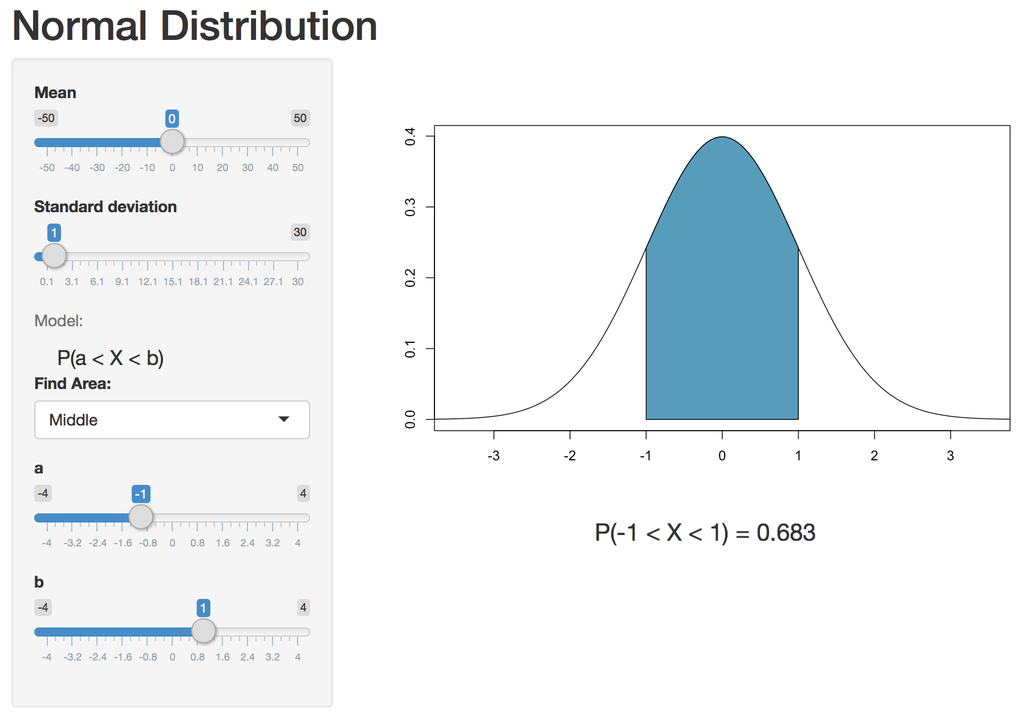

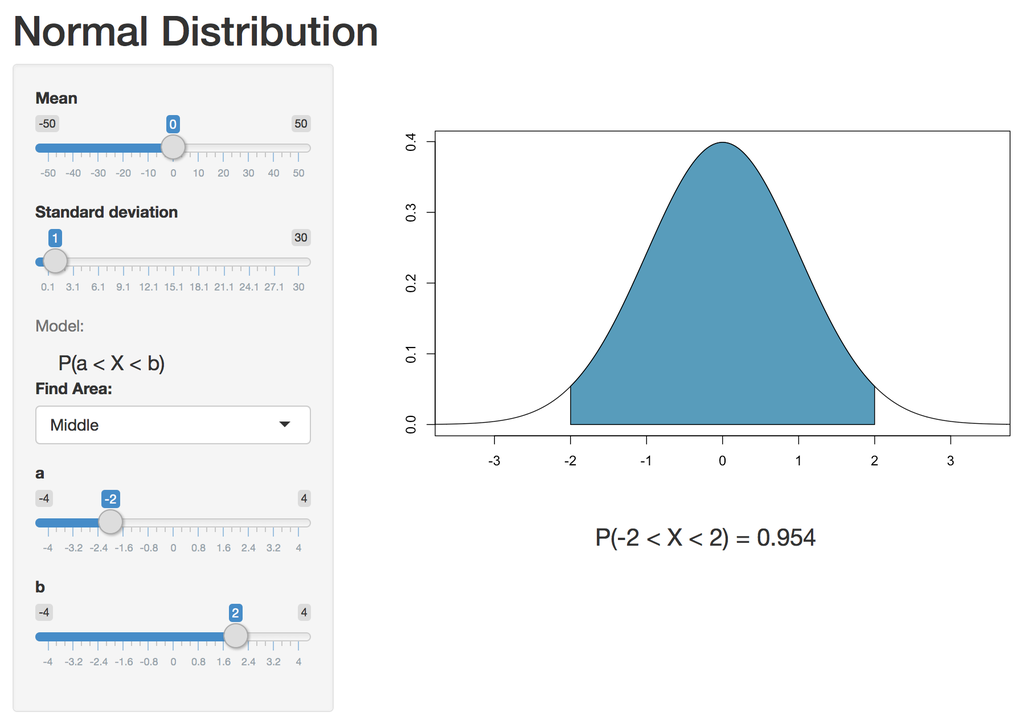

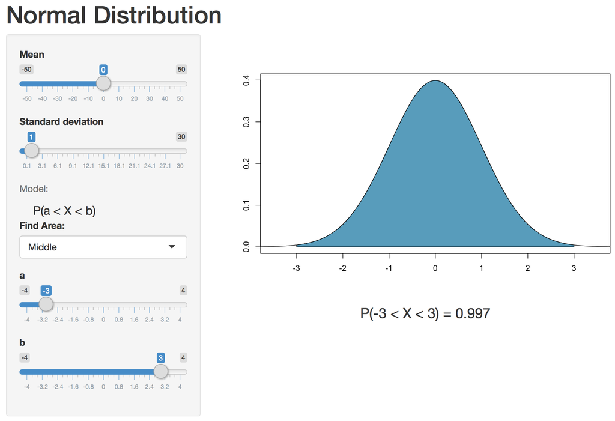

### Normal Distribution: R functions

```r
#dnorm: 5 sample normal distribution
xlim <- 0 + c(-1,1)*3.5*1;
x <- seq(xlim[1]-diff(range(xlim))/4, xlim[2]+diff(range(xlim))/4, length.out=5); y <- dnorm(x, mean=0, sd=1)
str(data.frame("x"=x,"y"=y))
```

```
'data.frame':   5 obs. of  2 variables:
 $ x: num  -5.25 -2.62 0 2.62 5.25
 $ y: num  4.13e-07 1.27e-02 3.99e-01 1.27e-02 4.13e-07
```

```r
#pnorm: Lower tail probability at -1.96
pnorm(-1.96, mean = 0, sd = 1, lower.tail = TRUE)
```

```
[1] 0.0249979
```

### Normal Distribution: Approximations

The central limit theorem implies that certain distributions can be approximated by the normal distribution.

- The binomial distribution B(n, p) is approximately normal with mean np and variance np(1-p) for large n and for p not too close to zero or one.
- The Poisson distribution with parameter \( \lambda \) is approximately normal with mean \( \lambda \) and variance \( \lambda \), for large values of \( \lambda \).
- The chi-squared distribution \( \chi^2 \)(k) is approximately normal with mean k and variance 2k, for large k.
- The Student's t-distribution t(v) is approximately normal with mean 0 and variance 1 when v reaches 30 for a 3.5% deviation at 95% of the upper tail. For 120 samples, the difference is less than 1%.